# Antimicrobial exposure is associated with decreased survival in triple-negative breast cancer

Ransohoff et al.

Feb 2022

# Manuscript tables and figures

## Main tables and figures

**Table 1:** Baseline sociodemographic and clinical characteristics of triple negative breast cancer patients by antibiotic use after diagnosis.

| **Characteristic** | **Antibiotic usage** **Ever user**, N = 654 | **Antibiotic usage** **Never user**, N = 118 | **Overall**, N = 772<sup>a</sup> | **p-value**<sup>b</sup> |  |  |
| --- | --- | --- | --- | --- | --- | --- |
| Age at diagnosis, n (%) |  |  |  |  |  | 0.77 |
| 21-34 | 48 (7.3) | 11 (9.3) | 59 (7.6) |  |  |  |
| 35-49 | 226 (35) | 44 (37) | 270 (35) |  |  |  |
| 50-64 | 243 (37) | 40 (34) | 283 (37) |  |  |  |
| 65-95 | 137 (21) | 23 (19) | 160 (21) |  |  |  |
| Socioeconomic status quintile, n (%) |  |  |  | 0.38 |  |  |
| 1 | 25 (3.8) | 7 (5.9) | 32 (4.1) |  |  |  |
| 2 | 64 (9.8) | 10 (8.5) | 74 (9.6) |  |  |  |
| 3 | 89 (14) | 17 (14) | 106 (14) |  |  |  |
| 4 | 123 (19) | 29 (25) | 152 (20) |  |  |  |
| 5 | 353 (54) | 55 (47) | 408 (53) |  |  |  |
| Race and ethnicity, n (%) |  |  |  | 0.46 |  |  |
| Non-Hispanic White | 477 (73) | 78 (66) | 555 (72) |  |  |  |
| Hispanic | 54 (8.3) | 11 (9.3) | 65 (8.4) |  |  |  |
| Asian/Pacific Islander | 94 (14) | 23 (19) | 117 (15) |  |  |  |
| Black | 29 (4.4) | 6 (5.1) | 35 (4.5) |  |  |  |
| Body mass index, n (%) |  |  |  | 0.012 |  |  |
| Underweight | 12 (1.8) | 0 (0) | 12 (1.6) |  |  |  |
| Normal | 217 (33) | 39 (33) | 256 (33) |  |  |  |
| Overweight | 113 (17) | 15 (13) | 128 (17) |  |  |  |
| Obese | 99 (15) | 9 (7.6) | 108 (14) |  |  |  |
| Unknown | 213 (33) | 55 (47) | 268 (35) |  |  |  |
| Ever publicly insured, n (%) | 135 (21) | 28 (24) | 163 (21) | 0.45 |  |  |
| Place of care, n (%) |  |  |  | 0.007 |  |  |
| Community | 315 (48) | 41 (35) | 356 (46) |  |  |  |
| University | 339 (52) | 77 (65) | 416 (54) |  |  |  |
| Stage, n (%) |  |  |  | 0.91 |  |  |
| I | 222 (34) | 39 (33) | 261 (34) |  |  |  |
| II | 325 (50) | 61 (52) | 386 (50) |  |  |  |
| III | 107 (16) | 18 (15) | 125 (16) |  |  |  |
| Tumor grade, n (%) |  |  |  | 0.17 |  |  |
| 1 | 21 (3.2) | 5 (4.2) | 26 (3.4) |  |  |  |
| 2 | 122 (19) | 14 (12) | 136 (18) |  |  |  |
| 3 | 479 (73) | 96 (81) | 575 (74) |  |  |  |
| Unknown | 32 (4.9) | 3 (2.5) | 35 (4.5) |  |  |  |
| Surgery type, n (%) |  |  |  | 0.013 |  |  |
| Lumpectomy | 323 (49) | 77 (65) | 400 (52) |  |  |  |
| Bilateral Mastectomy | 93 (14) | 14 (12) | 107 (14) |  |  |  |
| Unilateral Mastectomy | 221 (34) | 26 (22) | 247 (32) |  |  |  |
| No Surgery | 17 (2.6) | 1 (0.8) | 18 (2.3) |  |  |  |
| Received chemotherapy, n (%) | 522 (80) | 87 (74) | 609 (79) | 0.14 |  |  |
| Received radiotherapy, n (%) | 359 (55) | 70 (59) | 429 (56) | 0.37 |  |  |
| Germline BRCA1/2 pathogenic variant status, n (%) |  |  |  | 0.96 |  |  |
| Negative/VUS | 140 (21) | 24 (20) | 164 (21) |  |  |  |
| Positive | 51 (7.8) | 9 (7.6) | 60 (7.8) |  |  |  |
| Untested | 463 (71) | 85 (72) | 548 (71) |  |  |  |
| Ever low absolute neutrophil count (<1K/uL) post-diagnosis, n (%) | 142 (22) | 10 (8.5) | 152 (20) | <0.001 |  |  |
| Minimum absolute neutrophil count (K/uL) post-diagnosis, Median (IQR) | 2.12 (1.12 – 3.14) | 2.70 (1.83 – 3.79) | 2.26 (1.24 – 3.30) | <0.001 |  |  |
| Ever low absolute lymphocyte count (<1K/uL) post diagnosis, n (%) | 439 (67) | 48 (41) | 487 (63) | <0.001 |  |  |
| Minimum absolute lymphocyte count (K/uL) post-diagnosis, Median (IQR) | 0.70 (0.40 – 1.10) | 1.20 (0.70 – 1.67) | 0.76 (0.46 – 1.20) | <0.001 |  |  |
| Ever used growth factor support, n (%) | 287 (44) | 27 (23) | 314 (41) | <0.001 |  |  |
| Number of growth factor uses, Median (IQR) | 3.00 (2.00 – 4.00) | 2.00 (2.00 – 3.00) | 3.00 (2.00 – 4.00) | 0.004 |  |  |
| Unknown | 367 | 91 | 458 |  |  |  |
| Follow-up time (months), Median (IQR) | 104 (62 – 146) | 111 (58 – 159) | 104 (62 – 147) | 0.76 |  |  |

<sup>a</sup> n (%); Median (IQR)  
<sup>b</sup> Pearson's Chi-squared test; Fisher's exact test; Wilcoxon rank sum test

VUS: variant of unknown significance; body mass index was calculated as kg/m2, where kg is weight in kilograms and m2 is height in meters squared. Underweight was categorized as BMI under 18.5 kg/m2; normal as BMI greater than or equal to 18.5 to 24.9 kg/m2; overweight as BMI greater than or equal to 25 to 29.9 kg/m2; obese as BMI greater than or equal to 30 kg/m2.

**Figure 1:** Forest plot of adjusted survival associations with any, total, and unique antimicrobial exposures in the marginal structural Cox regression model.

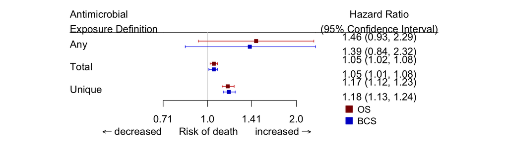

**Figure 2:** Weighted Kaplan-Meier estimates of overall and breast cancer-specific survival by any, total, and unique number of antimicrobial exposures.

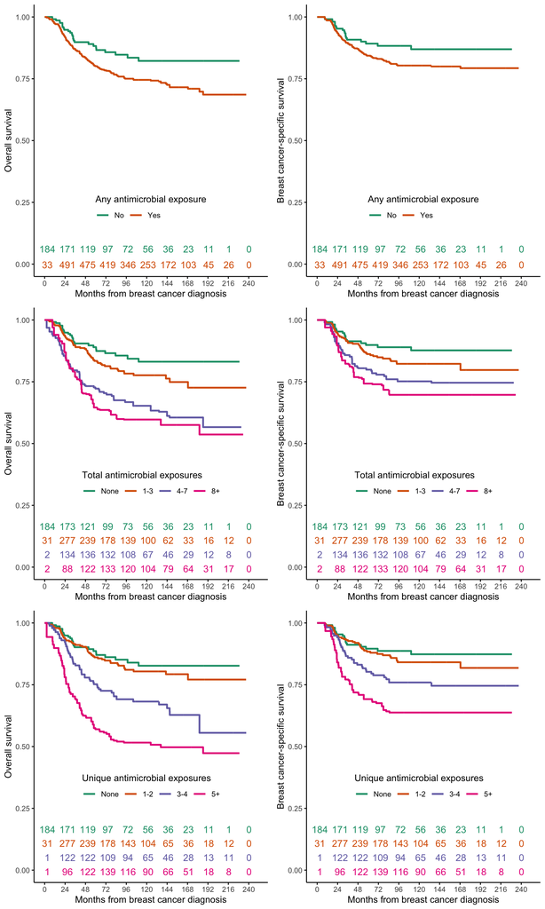

## Supplementary tables and figures

**Supplemental Table 1:** List of medications considered as antimicrobial exposures, immunosuppressives, and growth factors, and their administration routes.

| Medication | Administration |
| --- | --- |
| Antibiotic |  |
| Amikacin | IV or injection |
| Amoxicillin | pill or tablet, oral suspension |
| Ampicillin | pill or tablet, oral suspension, IV or injection |
| Azithromycin | pill or tablet, oral suspension |
| Aztreonam | pill or tablet, oral suspension |
| Bacitracin | IV or injection, topical, ophthalmic |
| Cefaclor | pill or tablet |
| Cefadroxil | pill or tablet, oral suspension |
| Cefazolin | IV or injection |
| Cefdinir | pill or tablet |
| Cefepime | IV or injection |
| Cefixime | pill or tablet |
| Cefotaxime | IV or injection |
| Cefoxitin | IV or injection |
| Cefpodoxime | pill or tablet |
| Cefprozil | pill or tablet |
| Ceftaroline | IV or injection |
| Ceftazidime | IV or injection |
| Ceftriaxone | IV or injection |
| Cefuroxime | pill or tablet, oral suspension |
| Cephalexin | pill or tablet, oral suspension |
| Ciprofloxacin | IV or injection, pill or tablet, oral suspension |
| Clarithromycin | pill or tablet, oral suspension |
| Clindamycin | pill or tablet, IV or injection |
| Colistin | IV or injection |
| Dapsone | pill or tablet |
| Daptomycin | IV or injection |
| Dicloxacillin | pill or tablet |
| Doxycycline | pill or tablet, IV or injection |

[output cut: 61 more lines]

**Supplemental Figure 1:** Flow diagram of patients meeting inclusion and exclusion criteria.

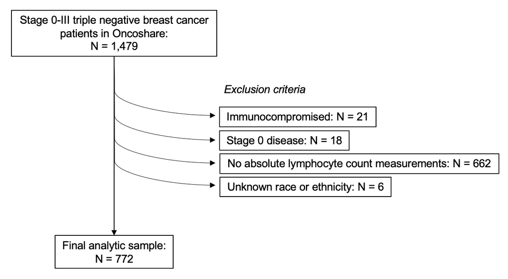

**Supplemental Figure 2:** Weighted distributions of total and unique antimicrobial prescriptions.

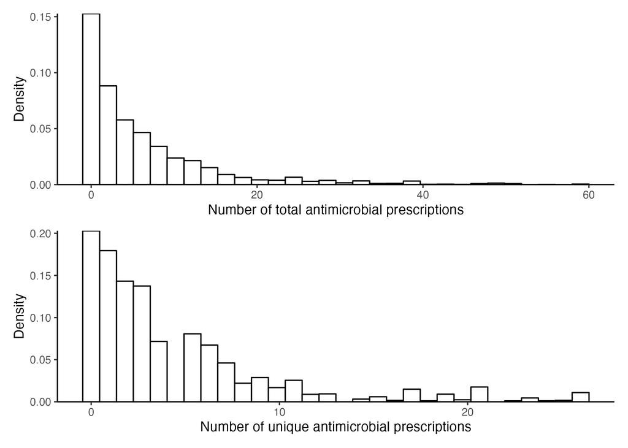

**Supplemental Table 2:** Inverse probability weighting results for any antimicrobial use.

| **Characteristic** | **Hazard Ratio (95% Confidence Interval)** | **p-value** |
| --- | --- | --- |
| Absolute lymphocyte count | 0.88 (0.78 to 0.99) | 0.040 |
| Age at diagnosis (per 1 year increase) | 1.01 (1.00 to 1.01) | 0.023 |
| Race and ethnicity |  |  |
| Non-Hispanic White | 1.0 |  |
| Hispanic | 0.93 (0.69 to 1.27) | 0.66 |
| Asian/Pacific Islander | 0.84 (0.66 to 1.05) | 0.12 |
| Black/African American | 0.85 (0.57 to 1.25) | 0.41 |
| Per quintile increase in neighborhood socioeconomic status | 1.00 (0.93 to 1.08) | >0.99 |
| Stage |  |  |
| I | 1.0 |  |
| II | 0.81 (0.68 to 0.98) | 0.028 |
| III | 0.80 (0.61 to 1.04) | 0.10 |
| Grade |  |  |
| 1 | 1.0 |  |
| 2 | 1.48 (0.92 to 2.37) | 0.11 |
| 3 | 1.36 (0.87 to 2.15) | 0.18 |
| Unknown | 1.13 (0.65 to 1.99) | 0.66 |
| Received chemotherapy |  |  |
| No | 1.0 |  |
| Yes | 1.15 (0.91 to 1.46) | 0.23 |
| Received radiotherapy |  |  |
| No | 1.0 |  |
| Yes | 0.97 (0.81 to 1.16) | 0.76 |
| Ever used growth factor support |  |  |
| No | 1.0 |  |
| Yes | 1.90 (1.60 to 2.27) | <0.001 |
| Surgery type |  |  |
| Lumpectomy | 1.0 |  |
| Bilateral Mastectomy | 1.61 (1.25 to 2.08) | <0.001 |
| Unilateral Mastectomy | 1.52 (1.25 to 1.85) | <0.001 |

HRs were adjusted for all listed covariates and reflect the risk of death for any antimicrobial use, defined as ever versus never receipt of antimicrobials during the study period. For age at diagnosis, HR indicates the risk of death per one year of age increase.

**Supplemental Table 3:** Inverse probability weighting results for total antimicrobial exposures.

| **Characteristic** | **Estimate (95% Confidence Interval)** | **p-value** |
| --- | --- | --- |
| Absolute lymphocyte count | 0.02 (0.00 to 0.04) | 0.015 |
| Age at diagnosis (per 1 year increase) | -0.01 (-0.02 to 0.00) | 0.056 |
| Race and ethnicity |  |  |
| Non-Hispanic White | 0.0 |  |
| Hispanic | -0.20 (-0.56 to 0.17) | 0.29 |
| Asian/Pacific Islander | -0.23 (-0.52 to 0.05) | 0.11 |
| Black/African American | -0.20 (-0.64 to 0.24) | 0.37 |
| Per quintile increase in neighborhood socioeconomic status | 0.05 (-0.05 to 0.15) | 0.31 |
| Stage |  |  |
| I | 0.0 |  |
| II | -0.10 (-0.39 to 0.19) | 0.50 |
| III | -0.62 (-1.0 to -0.22) | 0.002 |
| Grade |  |  |
| 1 | 0.0 |  |
| 2 | -0.32 (-0.95 to 0.31) | 0.32 |
| 3 | -0.52 (-1.2 to 0.12) | 0.11 |
| Unknown | -0.05 (-0.83 to 0.73) | 0.90 |
| Received chemotherapy |  |  |
| No | 0.0 |  |
| Yes | 0.08 (-0.23 to 0.40) | 0.61 |
| Received radiotherapy |  |  |
| No | 0.0 |  |
| Yes | -0.02 (-0.29 to 0.25) | 0.89 |
| Ever used growth factor support |  |  |
| No | 0.0 |  |
| Yes | 0.34 (0.02 to 0.66) | 0.038 |
| Surgery type |  |  |
| Lumpectomy | 0.0 |  |
| Bilateral Mastectomy | 0.30 (-0.09 to 0.69) | 0.14 |
| Unilateral Mastectomy | 0.30 (0.00 to 0.60) | 0.049 |

HRs were adjusted for all listed covariates and reflect the risk of death for each change in total number of per-month prescriptions. For age at diagnosis, HR indicates the risk of death per one year of age increase. For neighborhood socioeconomic status, HR represents the risk of death per increase in each socioeconomic status quintile.

**Supplemental Table 4:** Inverse probability weighting results for unique antimicrobial exposures.

| **Characteristic** | **Estimate (95% Confidence Interval)** | **p-value** |
| --- | --- | --- |
| Absolute lymphocyte count | 0.01 (0.00 to 0.02) | 0.072 |
| Age at diagnosis (per 1 year increase) | 0.00 (-0.01 to 0.00) | 0.50 |
| Race and ethnicity |  |  |
| Non-Hispanic White | 0.0 |  |
| Hispanic | -0.01 (-0.26 to 0.23) | 0.93 |
| Asian/Pacific Islander | -0.14 (-0.34 to 0.05) | 0.14 |
| Black/African American | -0.03 (-0.35 to 0.30) | 0.87 |
| Per quintile increase in neighborhood socioeconomic status | 0.05 (0.00 to 0.11) | 0.073 |
| Stage |  |  |
| I | 0.0 |  |
| II | -0.10 (-0.25 to 0.04) | 0.17 |
| III | -0.32 (-0.53 to -0.10) | 0.004 |
| Grade |  |  |
| 1 | 0.0 |  |
| 2 | -0.09 (-0.44 to 0.26) | 0.61 |
| 3 | -0.11 (-0.45 to 0.23) | 0.53 |
| Unknown | 0.11 (-0.32 to 0.53) | 0.62 |
| Received chemotherapy |  |  |
| No | 0.0 |  |
| Yes | 0.04 (-0.16 to 0.25) | 0.68 |
| Received radiotherapy |  |  |
| No | 0.0 |  |
| Yes | 0.01 (-0.15 to 0.17) | 0.92 |
| Ever used growth factor support |  |  |
| No | 0.0 |  |
| Yes | 0.32 (0.17 to 0.46) | <0.001 |
| Surgery type |  |  |
| Lumpectomy | 0.0 |  |
| Bilateral Mastectomy | 0.34 (0.14 to 0.54) | <0.001 |
| Unilateral Mastectomy | 0.28 (0.11 to 0.45) | 0.001 |

HRs were adjusted for all listed covariates and reflect the risk of death for each change in unique number of per-month prescriptions. For age at diagnosis, HR indicates the risk of death per one year of age increase. For neighborhood socioeconomic status, HR represents the risk of death per increase in each socioeconomic status quintile.

**Supplemental Table 5:** Multivariable-adjusted hazard ratios (HRs) for any, total, and unique antimicrobial exposures in the marginal structural Cox regression model (MSM).

| **Characteristic** | **Overall Survival** **N Events** | **Overall Survival** **Hazard Ratio (95% Confidence Interval)** | **Overall Survival** **p-value** | **Breast Cancer-Specific Survival** **N Events** | **Breast Cancer-Specific Survival** **Hazard Ratio (95% Confidence Interval)** | **Breast Cancer-Specific Survival** **p-value** |
| --- | --- | --- | --- | --- | --- | --- |
| Any antimicrobial exposure | 171 | 1.46 (0.93 to 2.29) | 0.10 | 124 | 1.39 (0.84 to 2.32) | 0.20 |
| Total antimicrobial exposures | 205 | 1.05 (1.02 to 1.08) | <0.001 | 142 | 1.05 (1.01 to 1.08) | 0.005 |
| Unique antimicrobial exposures | 200 | 1.17 (1.12 to 1.23) | <0.001 | 143 | 1.18 (1.13 to 1.24) | <0.001 |

HRs reflect the risk of death for any antimicrobial use, defined as ever versus never receipt of antimicrobials, and the risk of death for each change in cumulative number of per-month prescriptions for total and unique exposures during observation. MSMs were adjusted for the following variables: age at diagnosis, race and ethnicity, socioeconomic status quintile, cancer stage, tumor grade, receipt of chemotherapy, receipt of radiotherapy, ever use of growth factor support, and surgery type

**Supplemental Table 6:** Unweighted versus marginal structural model adjusted hazard ratios to remove the impact of absolute neutrophil count on all-cause and breast cancer-specific survival.

| **Characteristic** | **Overall Survival** **Unweighted** | **Overall Survival** **Marginal Structural Model** | **Breast Cancer-Specific Survival** **Unweighted** | **Breast Cancer-Specific Survival** **Marginal Structural Model** |
| --- | --- | --- | --- | --- |
| Any antimicrobial exposure | 1.58 (1.01 to 2.49) | 1.58 (1.01 to 2.48) | 1.53 (0.92 to 2.54) | 1.52 (0.92 to 2.53) |

Hazard Ratio (95% Confidence Interval); HRs were adjusted for all variables adjusted for in the marginal structural model. ANC: absolute neutrophil count.

**Supplemental Table 7:** Marginal structural model adjusted for disease severity.

| **Characteristic** | **Overall Survival** **N Events** | **Overall Survival** **Hazard Ratio (95% Confidence Interval)** | **Overall Survival** **p-value** | **Breast Cancer-Specific Survival** **N Events** | **Breast Cancer-Specific Survival** **Hazard Ratio (95% Confidence Interval)** | **Breast Cancer-Specific Survival** **p-value** |
| --- | --- | --- | --- | --- | --- | --- |
| Any antimicrobial exposure | 169 | 1.45 (0.93 to 2.28) | 0.10 | 122 | 1.40 (0.84 to 2.34) | 0.20 |
| Acute illness |  | 2.07 (1.24 to 3.46) | 0.005 |  | 1.74 (0.90 to 3.36) | 0.10 |
| Total antimicrobial exposures | 218 | 1.05 (1.02 to 1.08) | <0.001 | 154 | 1.05 (1.02 to 1.09) | 0.001 |
| Acute illness |  | 2.56 (1.42 to 4.62) | 0.002 |  | 2.27 (0.99 to 5.17) | 0.052 |
| Unique antimicrobial exposures | 197 | 1.16 (1.11 to 1.21) | <0.001 | 142 | 1.17 (1.12 to 1.23) | <0.001 |
| Acute illness |  | 1.82 (1.09 to 3.02) | 0.021 |  | 1.61 (0.82 to 3.16) | 0.16 |

In addition to adjusting for acute illness, HRs were adjusted for all variables adjusted for in the marginal structural model.

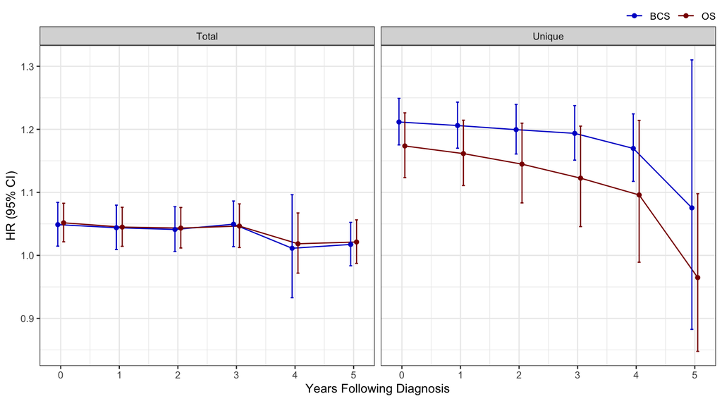